# R Notebook

# Distributions homework

### Pre-analysis

The database contains details of mobile phones and their customer reviews on an online shopping site. Each row in the data corresponds to one model of mobile phone. A statistical analysis is carried out to investigate the given dataset.

The following packages are loaded in this work for our analysis.

```r
library(prob)
library(tidyverse)
library(janitor)
library(skimr)
```

```r
# read in dates as strings
reviews_data <- read_csv("data/20190928-items.csv")
```

### MVP

We first re-write the names from our dataset - we use the snake_case style

| asin | brand | title | url | image | rating | review_url | total_reviews | prices |
| --- | --- | --- | --- | --- | --- | --- | --- | --- |
| B0000SX2UC | Nokia | Dual-Band / Tri-Mode Sprint PCS Phone w/ Voice Activated Dialing & Bright White Backlit Screen | https://www.amazon.com/Dual-Band-Tri-Mode-Activated-Dialing-Backlit/dp/B0000SX2UC | https://m.media-amazon.com/images/I/2143EBQ210L._AC_UY218_SEARCH213888_FMwebp_QL75_.jpg | 3.0 | https://www.amazon.com/product-reviews/B0000SX2UC | 14 | NA |
| B0009N5L7K | Motorola | Motorola I265 phone | https://www.amazon.com/Motorola-i265-I265-phone/dp/B0009N5L7K | https://m.media-amazon.com/images/I/419WBAVDARL._AC_UY218_SEARCH213888_FMwebp_QL75_.jpg | 2.9 | https://www.amazon.com/product-reviews/B0009N5L7K | 7 | $49.95 |

*Question: Find the brand with the highest numbers of phones in the dataset.*

```r
number_of_phones <- clean_reviews_data %>%
  select(brand) %>%
  group_by(brand) %>%
  summarise(highest_number_of_phones = n()) %>%
  arrange(desc(highest_number_of_phones))
```

*Question: For your top brand, plot the distribution of phone ratings as a probability density, overlaying a fitted normal distribution. Do you think the normal distribution provides a good model of these ratings?*

The Samsung phones are storaged in an object called **samsung_phones**.

| brand | rating | prices |
| --- | --- | --- |
| Samsung | 3.5 | $59.89 |
| Samsung | 2.9 | $149.95 |
| Samsung | 2.8 | NA |
| Samsung | 2.6 | NA |
| Samsung | 3.2 | NA |
| Samsung | 2.0 | NA |
| Samsung | 3.4 | NA |
| Samsung | 3.5 | $79.99 |
| Samsung | 3.4 | NA |
| Samsung | 3.4 | NA |

[output cut: 387 more lines]

Some statistical analysis is carried out first for the Samsung phones. The folowing command is used to get the statistical information (note, the skim( ) function can be also used). The customer-review-rating of Samsung phones has a mean value of 3.57 and a median of 3.6. The standard deviation is 0.685. Its IQR is 0.6 and the range between the minimum and maximum value of the customer-review-rating is, respectively, 1 and 5.

```r
samsung_phones_stats <- samsung_phones %>%
  summarise(
    num = n(),
    mean = mean(rating),
    sd = sd(rating),
    Q0 = quantile(rating, 0.00),
    Q1 = quantile(rating, 0.25),
    Q2 = quantile(rating, 0.50),
    Q3 = quantile(rating, 0.72),
    Q4 = quantile(rating, 1.00),
    IQR = Q3-Q1
  )
samsung_phones_stats
```

| num | mean | sd | Q0 | Q1 | Q2 | Q3 | Q4 | IQR |
| --- | --- | --- | --- | --- | --- | --- | --- | --- |
| 397 | 3.5733 | 0.6847859 | 1 | 3.3 | 3.6 | 3.9 | 5 | 0.6 |

The histogram of the probabbility density of Samsung phones with respect to their customer-review-rating is presented below alomng with a fitted normal distribution. The customer-review-rating is divided into 10 intervals.

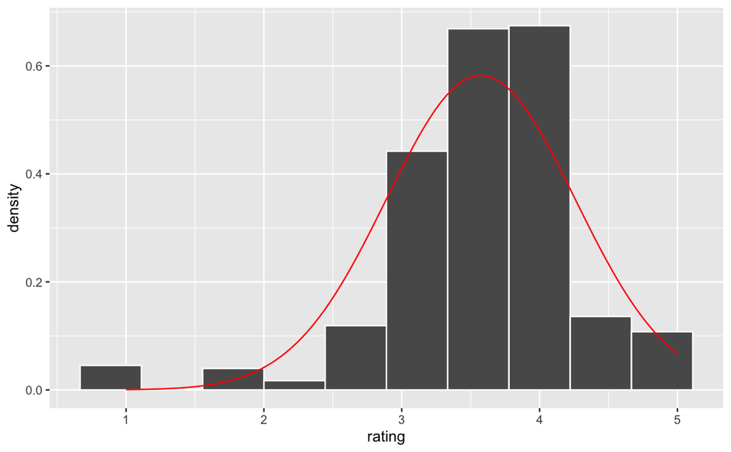

```r
samsung_phones %>%
  ggplot()+
  aes(x = rating) +
  geom_histogram(aes(y = ..density..),col = "white", bins = 10)+
  stat_function(
    fun = dnorm,
    args = list(
      mean = samsung_phones_stats$mean,
      sd = samsung_phones_stats$sd
    ),
    col = "red"
  )
```

```r
NA
```

*Question: We can be more quantitative in comparing the distribution of top brand ratings with a normal distribution. Use the mean() and sd() to calculate the proportions of ratings within one-, two- and three standard deviations of the mean. Compare these proportions with those you expect for a normal distribution.*

We first define a normal distribution and we calculate the proportions of ratings within:

one-standard deviations of the mean (68.3%),

```r
100 * (pnorm(q = 1) - pnorm(q = -1))
```

```
[1] 68.26895
```

two-standard deviations of the mean (95.4%)

```r
100 * (pnorm(q = 2) - pnorm(q = -2))
```

```
[1] 95.44997
```

```r
100 * (pnorm(q = 3) - pnorm(q = -3))
```

```
[1] 99.73002
```

```r
100 * (pnorm(q = 1, mean =3.6, 0.68) - pnorm(q = -1, mean =3.6, 0.68))
```

```
[1] 0.006577744
```

```r
100 * (pnorm(q = 2, mean =3.6, 0.68) - pnorm(q = -2, mean =3.6, 0.68))
```

```
[1] 0.931279
```

```r
100 * (pnorm(q = 3, mean =3.6, 0.68) - pnorm(q = -3, mean =3.6, 0.68))
```

```
[1] 18.8793
```